# Assignment_2

Kevin McMorrow

3/6/2019

## QAC305 - Assignment 2

## Problem 1

Load in necessary libraries and the data set

```r
library(factorAnalysis)
library(devtools)
library(factoextra)
library(psych)
library(mice)
library(VIM)
library(missForest)
load(file = "prof_salary.rdata")
```

## Problem 2

```r
round(colMeans(is.na(prof_salary)), 2)
```

```
##          rank    discipline yrs.since.phd   yrs.service           sex
##          0.00          0.00          0.00          0.13          0.00
##        salary
##          0.07
```

## Problem 3

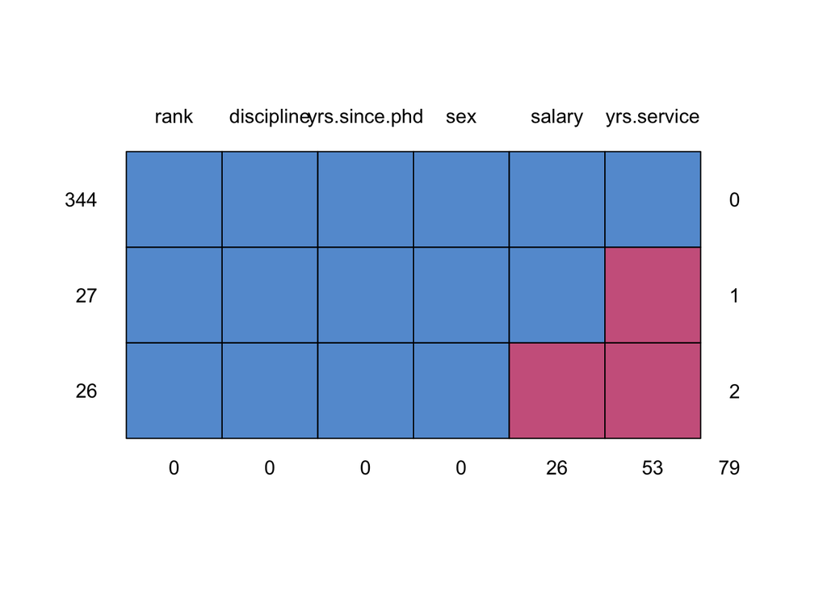

```
##     rank discipline yrs.since.phd sex salary yrs.service
## 344    1          1             1   1      1           1  0
## 27     1          1             1   1      1           0  1
## 26     1          1             1   1      0           0  2
##        0          0             0   0     26          53 79
```

```r
md.pattern(prof_salary)
```

When “salary” is missing, “years of service”" is usually missing as well. When “years of service” is missing, it does not necessarily mean that “salary” will be missing. There is a correlation between missing values on salary and missing values on years of service.

## Problem 4

```r
prof_salary2 = prof_salary

prof_salary2$yrs.service = ifelse(is.na(prof_salary$yrs.service), 1, 2)
prof_salary2$salary = ifelse(is.na(prof_salary$salary), 1, 2)

cor(x = prof_salary2$salary, y = prof_salary2$yrs.service, method = "pearson")
```

```
## [1] 0.6744364
```

A value of 0.6744364 tells us that there is a rather strong correlation between missing values of salary and years of service.

## Problem 5

```r
prof_salary3 = na.omit(prof_salary)
fit_complete = lm(salary ~ ., data = prof_salary3)
summary(fit_complete)
```

```
##
## Call:
## lm(formula = salary ~ ., data = prof_salary3)
##
## Residuals:
##    Min     1Q Median     3Q    Max
## -66155 -11855  -1098   9693  82357
##
## Coefficients:
##               Estimate Std. Error t value Pr(>|t|)
## (Intercept)    65953.6     4047.0  16.297  < 2e-16 ***
## rankAssocProf  13245.8     3629.9   3.649 0.000305 ***
## rankProf       44564.6     3845.4  11.589  < 2e-16 ***
## disciplineB    16525.9     2171.9   7.609 2.79e-13 ***
## yrs.since.phd    312.3      246.1   1.269 0.205320
## yrs.service     -257.0      217.2  -1.183 0.237574
## sexMale         3866.7     3326.3   1.162 0.245870
## ---
## Signif. codes:  0 '***' 0.001 '**' 0.01 '*' 0.05 '.' 0.1 ' ' 1
##
## Residual standard error: 19360 on 337 degrees of freedom
## Multiple R-squared:  0.5393, Adjusted R-squared:  0.5311
## F-statistic: 65.75 on 6 and 337 DF,  p-value: < 2.2e-16
```

## Problem 6

```r
data=prof_salary
newdata <- kNN(data,
               variable=colnames(data),
               k=5,
               dist_var=colnames(data),
               numFun = median,
               catFun = maxCat,
               weightDist = FALSE,
               imp_var = F,
               trace = FALSE)
fit_complete2 = lm(salary ~ ., data = newdata)
summary(fit_complete2)
```

```
##
## Call:
## lm(formula = salary ~ ., data = newdata)
##
## Residuals:
##    Min     1Q Median     3Q    Max
## -64455 -13064  -1258  11290  99482
##
## Coefficients:
##               Estimate Std. Error t value Pr(>|t|)
## (Intercept)    68002.4     4271.0  15.922  < 2e-16 ***
## rankAssocProf  14395.1     3866.3   3.723 0.000226 ***
## rankProf       46033.6     3937.4  11.691  < 2e-16 ***
## disciplineB    13949.1     2178.1   6.404 4.35e-10 ***
## yrs.since.phd    125.7      232.5   0.541 0.588932
## yrs.service     -131.8      217.4  -0.607 0.544490
## sexMale         4178.2     3600.1   1.161 0.246520
## ---
## Signif. codes:  0 '***' 0.001 '**' 0.01 '*' 0.05 '.' 0.1 ' ' 1
##
## Residual standard error: 21020 on 390 degrees of freedom
## Multiple R-squared:  0.4697, Adjusted R-squared:  0.4616
## F-statistic: 57.58 on 6 and 390 DF,  p-value: < 2.2e-16
```

## Problem 7

```r
set.seed(1234)
forest = missForest(prof_salary)
```

```
##   missForest iteration 1 in progress...done!
##   missForest iteration 2 in progress...done!
##   missForest iteration 3 in progress...done!
##   missForest iteration 4 in progress...done!
##   missForest iteration 5 in progress...done!
```

```r
forest_rf = forest$ximp

fit_complete3 = lm(salary ~ ., data = forest_rf)
summary(fit_complete3)
```

```
##
## Call:
## lm(formula = salary ~ ., data = forest_rf)
##
## Residuals:
##    Min     1Q Median     3Q    Max
## -62939 -12793  -1880   9223 100146
##
## Coefficients:
##                 Estimate Std. Error t value Pr(>|t|)
## (Intercept)   68389.0914  4192.6185  16.312  < 2e-16 ***
## rankAssocProf 14728.9877  3803.0703   3.873 0.000126 ***
## rankProf      47577.0794  3871.1804  12.290  < 2e-16 ***
## disciplineB   14650.6378  2141.6028   6.841 3.06e-11 ***
## yrs.since.phd     0.1958   229.6028   0.001 0.999320
## yrs.service     -87.6881   223.4840  -0.392 0.695000
## sexMale        3818.2126  3541.5313   1.078 0.281644
## ---
## Signif. codes:  0 '***' 0.001 '**' 0.01 '*' 0.05 '.' 0.1 ' ' 1
##
## Residual standard error: 20680 on 390 degrees of freedom
## Multiple R-squared:  0.479,  Adjusted R-squared:  0.471
## F-statistic: 59.75 on 6 and 390 DF,  p-value: < 2.2e-16
```

## Problem 8

This mechanism would be “missing not at random”.

## Problem 9

```r
summary(fit_complete) #list-wise
```

```
##
## Call:
## lm(formula = salary ~ ., data = prof_salary3)
##
## Residuals:
##    Min     1Q Median     3Q    Max
## -66155 -11855  -1098   9693  82357
##
## Coefficients:
##               Estimate Std. Error t value Pr(>|t|)
## (Intercept)    65953.6     4047.0  16.297  < 2e-16 ***
## rankAssocProf  13245.8     3629.9   3.649 0.000305 ***
## rankProf       44564.6     3845.4  11.589  < 2e-16 ***
## disciplineB    16525.9     2171.9   7.609 2.79e-13 ***
## yrs.since.phd    312.3      246.1   1.269 0.205320
## yrs.service     -257.0      217.2  -1.183 0.237574
## sexMale         3866.7     3326.3   1.162 0.245870
## ---
## Signif. codes:  0 '***' 0.001 '**' 0.01 '*' 0.05 '.' 0.1 ' ' 1
##
## Residual standard error: 19360 on 337 degrees of freedom
## Multiple R-squared:  0.5393, Adjusted R-squared:  0.5311
## F-statistic: 65.75 on 6 and 337 DF,  p-value: < 2.2e-16
```

```r
summary(fit_complete2) #knn
```

```
##
## Call:
## lm(formula = salary ~ ., data = newdata)
##
## Residuals:
##    Min     1Q Median     3Q    Max
## -64455 -13064  -1258  11290  99482
##
## Coefficients:
##               Estimate Std. Error t value Pr(>|t|)
## (Intercept)    68002.4     4271.0  15.922  < 2e-16 ***
## rankAssocProf  14395.1     3866.3   3.723 0.000226 ***
## rankProf       46033.6     3937.4  11.691  < 2e-16 ***
## disciplineB    13949.1     2178.1   6.404 4.35e-10 ***
## yrs.since.phd    125.7      232.5   0.541 0.588932
## yrs.service     -131.8      217.4  -0.607 0.544490
## sexMale         4178.2     3600.1   1.161 0.246520
## ---
## Signif. codes:  0 '***' 0.001 '**' 0.01 '*' 0.05 '.' 0.1 ' ' 1
##
## Residual standard error: 21020 on 390 degrees of freedom
## Multiple R-squared:  0.4697, Adjusted R-squared:  0.4616
## F-statistic: 57.58 on 6 and 390 DF,  p-value: < 2.2e-16
```

```r
summary(fit_complete3) #mF
```

```
##
## Call:
## lm(formula = salary ~ ., data = forest_rf)
##
## Residuals:
##    Min     1Q Median     3Q    Max
## -62939 -12793  -1880   9223 100146
##
## Coefficients:
##                 Estimate Std. Error t value Pr(>|t|)
## (Intercept)   68389.0914  4192.6185  16.312  < 2e-16 ***
## rankAssocProf 14728.9877  3803.0703   3.873 0.000126 ***
## rankProf      47577.0794  3871.1804  12.290  < 2e-16 ***
## disciplineB   14650.6378  2141.6028   6.841 3.06e-11 ***
## yrs.since.phd     0.1958   229.6028   0.001 0.999320
## yrs.service     -87.6881   223.4840  -0.392 0.695000
## sexMale        3818.2126  3541.5313   1.078 0.281644
## ---
## Signif. codes:  0 '***' 0.001 '**' 0.01 '*' 0.05 '.' 0.1 ' ' 1
##
## Residual standard error: 20680 on 390 degrees of freedom
## Multiple R-squared:  0.479,  Adjusted R-squared:  0.471
## F-statistic: 59.75 on 6 and 390 DF,  p-value: < 2.2e-16
```

## Problem 10

We would use list-wise deletion only if we have a lot of data, and the missing data is “MCAR”, or missing completely at random.

kNN imputation is suitable for smaller data sets (like the prof_salary data set).

randomForest imputation is best used with large data sets, as it is a sophisticated process and tends to overfit smaller data sets.